# Week 4 Assignment

CY Zheng

## Background and Data

Using devices such as Jawbone Up, Nike FuelBand, and Fitbit it is now possible to collect a large amount of data about personal activity relatively inexpensively. These type of devices are part of the quantified self movement – a group of enthusiasts who take measurements about themselves regularly to improve their health, to find patterns in their behavior, or because they are tech geeks. One thing that people regularly do is quantify how much of a particular activity they do, but they rarely quantify how well they do it. In this project, your goal will be to use data from accelerometers on the belt, forearm, arm, and dumbell of 6 participants. They were asked to perform barbell lifts correctly and incorrectly in 5 different ways. More information is available from the website here: http://web.archive.org/web/20161224072740/http:/groupware.les.inf.puc-rio.br/har (see the section on the Weight Lifting Exercise Dataset).

The training data for this project are available here:

https://d396qusza40orc.cloudfront.net/predmachlearn/pml-training.csv

The test data are available here:

https://d396qusza40orc.cloudfront.net/predmachlearn/pml-testing.csv

## Loading Data and Libraries

First load the data and the libraries needed.

```r
library(caret)
library(rpart)
library(rpart.plot)
library(ggplot2)


training_data <- read.csv("https://d396qusza40orc.cloudfront.net/predmachlearn/pml-training.csv")
test_data <- read.csv("https://d396qusza40orc.cloudfront.net/predmachlearn/pml-testing.csv")
```

## Processing Data

First remove the variables with nearly zero variance

```r
nearzero <- nearZeroVar(training_data)
training_data <- training_data[,-nearzero]
```

Then remove the variables contain more than 95% NAs.

```r
MostNA <- colSums(is.na(training_data))/nrow(training_data) < 0.95
training_data <- training_data[,MostNA]
```

Next remove the first 5 columns since they are irrelevant to our model.

```r
training_data <- training_data[,-(1:5)]
```

Finally, let us divide the training set into training and cross validation sets.

```r
inTrain <- createDataPartition(training_data$classe, p = 0.7, list = FALSE)
training <- training_data[inTrain,]
testing <- training_data[-inTrain,]
dim(training)
```

```
## [1] 13737    54
```

```r
dim(testing)
```

```
## [1] 5885   54
```

## Algorithm 1: Decision Tree

First we predict with decision tree.

```r
DTmodFit <- train(classe ~ ., method = 'rpart', data = training)
DTpred <- predict(DTmodFit, newdata = testing)
DTconf <- confusionMatrix(DTpred,testing$classe)
DTconf
```

```
## Confusion Matrix and Statistics
##
##           Reference
## Prediction    A    B    C    D    E
##          A 1515  502  171  347   58
##          B   35  356   41  116  183
##          C  120  281  814  457  176
##          D    0    0    0    0    0
##          E    4    0    0   44  665
##
## Overall Statistics
##
##                Accuracy : 0.5692
##                  95% CI : (0.5565, 0.5819)
##     No Information Rate : 0.2845
##     P-Value [Acc > NIR] : < 2.2e-16
##
##                   Kappa : 0.4432
##
##  Mcnemar's Test P-Value : < 2.2e-16
##
## Statistics by Class:
##
##                      Class: A Class: B Class: C Class: D Class: E
## Sensitivity            0.9050  0.31255   0.7934   0.0000   0.6146
## Specificity            0.7440  0.92099   0.7872   1.0000   0.9900
## Pos Pred Value         0.5843  0.48700   0.4405      NaN   0.9327
## Neg Pred Value         0.9517  0.84808   0.9475   0.8362   0.9194
## Prevalence             0.2845  0.19354   0.1743   0.1638   0.1839
## Detection Rate         0.2574  0.06049   0.1383   0.0000   0.1130
## Detection Prevalence   0.4406  0.12421   0.3140   0.0000   0.1212
## Balanced Accuracy      0.8245  0.61677   0.7903   0.5000   0.8023
```

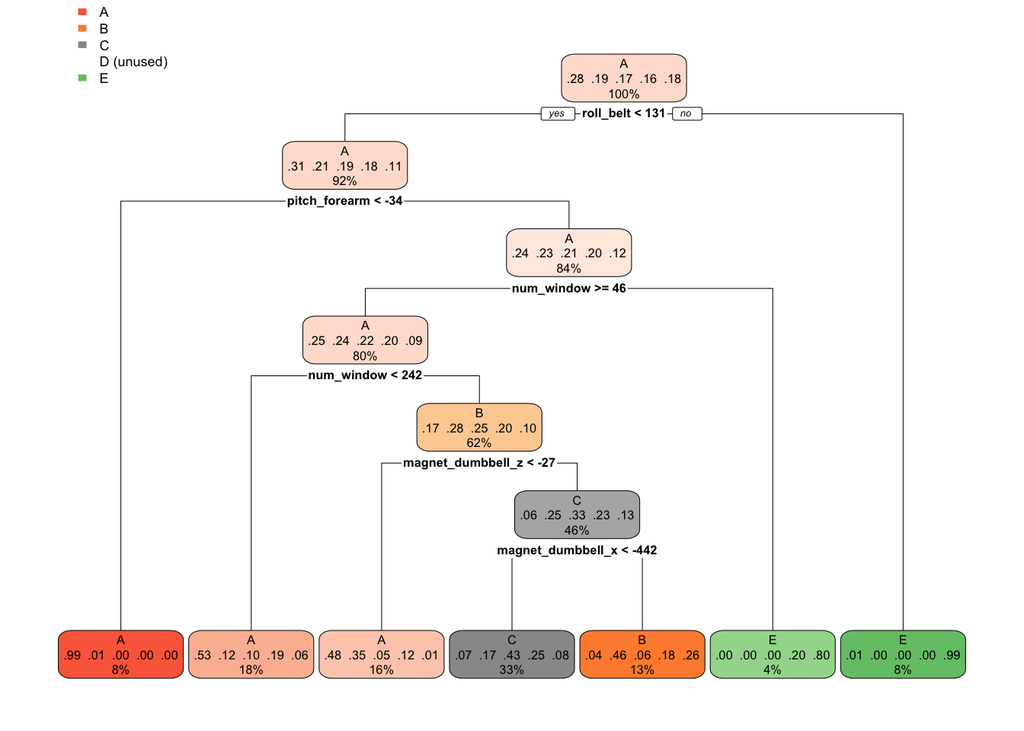

```r
rpart.plot(DTmodFit$finalModel)
```

The predict accuracy for decision tree is 0.5692.

## Algorithm 2: Random Forest

Here we need to use parallel processing to speed up computation.

```r
set.seed(111)

# configure parallel processing and run the model
library(parallel)
library(doParallel)
cluster <- makeCluster(detectCores() - 1) # convention to leave 1 core for OS
registerDoParallel(cluster)

fitcontrol <-  trainControl(method = "cv", number = 5, allowParallel = TRUE)
RFmodFit <- train(classe ~ ., data = training, method = 'rf',trControl = fitcontrol)
RFmodFit
```

```
## Random Forest
##
## 13737 samples
##    53 predictor
##     5 classes: 'A', 'B', 'C', 'D', 'E'
##
## No pre-processing
## Resampling: Cross-Validated (5 fold)
## Summary of sample sizes: 10990, 10990, 10990, 10989, 10989
## Resampling results across tuning parameters:
##
##   mtry  Accuracy   Kappa
##    2    0.9933756  0.9916204
##   27    0.9972337  0.9965007
##   53    0.9946858  0.9932777
##
## Accuracy was used to select the optimal model using the largest value.
## The final value used for the model was mtry = 27.
```

```r
# Prediction on test dataset
RFpred <- predict(RFmodFit,newdata=testing)
RFconf<- confusionMatrix(RFpred,testing$classe)
RFconf
```

```
## Confusion Matrix and Statistics
##
##           Reference
## Prediction    A    B    C    D    E
##          A 1673    2    0    0    0
##          B    0 1137    1    0    0
##          C    0    0 1025    1    0
##          D    0    0    0  963    5
##          E    1    0    0    0 1077
##
## Overall Statistics
##
##                Accuracy : 0.9983
##                  95% CI : (0.9969, 0.9992)
##     No Information Rate : 0.2845
##     P-Value [Acc > NIR] : < 2.2e-16
##
##                   Kappa : 0.9979
##
##  Mcnemar's Test P-Value : NA
##
## Statistics by Class:
##
##                      Class: A Class: B Class: C Class: D Class: E
## Sensitivity            0.9994   0.9982   0.9990   0.9990   0.9954
## Specificity            0.9995   0.9998   0.9998   0.9990   0.9998
## Pos Pred Value         0.9988   0.9991   0.9990   0.9948   0.9991
## Neg Pred Value         0.9998   0.9996   0.9998   0.9998   0.9990
## Prevalence             0.2845   0.1935   0.1743   0.1638   0.1839
## Detection Rate         0.2843   0.1932   0.1742   0.1636   0.1830
## Detection Prevalence   0.2846   0.1934   0.1743   0.1645   0.1832
## Balanced Accuracy      0.9995   0.9990   0.9994   0.9990   0.9976
```

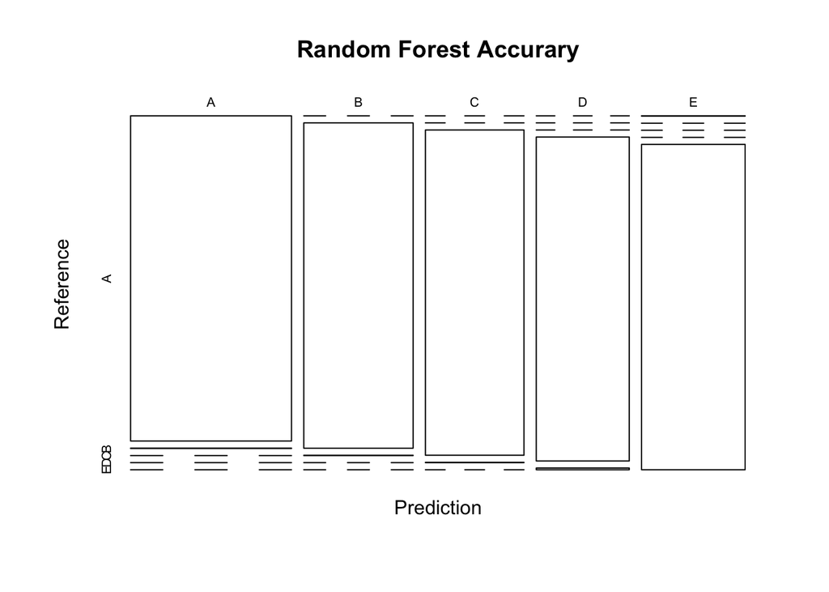

```r
# Plot results
plot(RFconf$table, col = RFconf$byClass,main = 'Random Forest Accurary')
```

Then we can see that the prediction accuracy is 0.9983

## Algorithm 3: Boosting

```r
BOmodFit <- train(classe ~ ., data = training, method = 'gbm',verbose = FALSE)
BOmodFit
```

```
## Stochastic Gradient Boosting
##
## 13737 samples
##    53 predictor
##     5 classes: 'A', 'B', 'C', 'D', 'E'
##
## No pre-processing
## Resampling: Bootstrapped (25 reps)
## Summary of sample sizes: 13737, 13737, 13737, 13737, 13737, 13737, ...
## Resampling results across tuning parameters:
##
##   interaction.depth  n.trees  Accuracy   Kappa
##   1                   50      0.7549021  0.6889948
##   1                  100      0.8266374  0.7805262
##   1                  150      0.8652253  0.8293972
##   2                   50      0.8806173  0.8488239
##   2                  100      0.9351680  0.9179317
##   2                  150      0.9581406  0.9470147
##   3                   50      0.9284908  0.9094633
##   3                  100      0.9663931  0.9574624
##   3                  150      0.9825090  0.9778641
##
## Tuning parameter 'shrinkage' was held constant at a value of 0.1
##
## Tuning parameter 'n.minobsinnode' was held constant at a value of 10
## Accuracy was used to select the optimal model using the largest value.
## The final values used for the model were n.trees = 150,
##  interaction.depth = 3, shrinkage = 0.1 and n.minobsinnode = 10.
```

```r
# Prediction on test dataset
BOpred <- predict(BOmodFit,newdata=testing)
BOconf<- confusionMatrix(RFpred,testing$classe)
BOconf
```

[output not shown]

[figure not shown]

```r
# Plot results
plot(BOconf$table, col = BOconf$byClass,main = 'Boosting Accurary')
```

## Prediction

```r
predict(RFmodFit,test_data)
```

```
##  [1] B A B A A E D B A A B C B A E E A B B B
## Levels: A B C D E
```